# **0. Importing Libraries and Setting Random State**

```python
import numpy as np
import pandas as pd
import matplotlib.pyplot as plt
import seaborn as sns

from sklearn.preprocessing import StandardScaler
from sklearn.neighbors import KernelDensity
from sklearn.cluster import KMeans
from sklearn.metrics import adjusted_rand_score
from sklearn.model_selection import train_test_split

import hdbscan

from mpl_toolkits.mplot3d import Axes3D
from matplotlib import cm

sns.set_theme(style="white", context="talk")
np.random.seed(42)
```

# **1. Creating synthetic customer data**

We simulate realistic customer segments in 2D:

- Annual Spending (EUR)
- Visit Frequency per Year

The segments have NONLINEAR shapes to demonstrate HDBSCAN's strengths compared to k-means.

### **1.1 Context of the Data and Costumer Segments**

We imagine being in a touristic place such as South Tyrol and to be the Data Analyst of a Pizzaria in the City Center of Bolzano. The Pizzaria is sorrounded by offices (Working People), a University (Poor Students) and the Piazza Walther (Rich Tourists). In this context we will identify the following costumer segments:

**Segment 0 - Students: Low-Value Loyal Costumers**:  
The Students eat quite frequently at the Pizzaria (depending on their time table), but do not spent a lot for food.

**Segment 1 - Working People: Loyal Costumers**:  
Within the working people we have the highest frequency. But the higher the frequency the lower the annual spending. This could be related to the fact that business-dinners (=> high spendings) take place fewer than regular lunches of the emplyees.

**Segment 2 - Tourists: High-Value Non-Loyal Costumers**:  
Tourists have the least frequency but spend the most.

Note: Noise-Values are labeled as -1.

```python
# Segment A: Low-Value Customers (slightly curved)
xA = np.random.uniform(2, 40, 450)
yA = 80 + 10 * np.log(xA) + np.random.normal(0, 12, 450)

# Segment B: High-Frequency Smart Shoppers (saturating curve)
xB = np.random.uniform(25, 80, 300)
yB = 400 + 180 * (1 - np.exp(-xB / -70)) + np.random.normal(0, 20, 300)

# Segment C: High-Value Loyalists (nonlinear sine pattern)
xC = np.random.uniform(2, 20, 260)
yC = 400 + 200 * np.sin(xC / 8) + np.random.normal(0, 25, 260)

# Noise / Outlier customers
xN = np.random.uniform(0, 100, 120)
yN = np.random.uniform(0, 1500, 120)

# Combine
X = np.column_stack([
    np.concatenate([xA, xB, xC, xN]),
    np.concatenate([yA, yB, yC, yN])
])

# True labels
y_true = np.concatenate([
    np.zeros(len(xA)),
    np.ones(len(xB)),
    2 * np.ones(len(xC)),
    -1 * np.ones(len(xN))  # Noise
])

df = pd.DataFrame(X, columns=["Visits_per_Year", "Annual_Spending"])
df["Segment_true"] = y_true
len(df)
```

```
1130
```

# **2. Data Exploration**

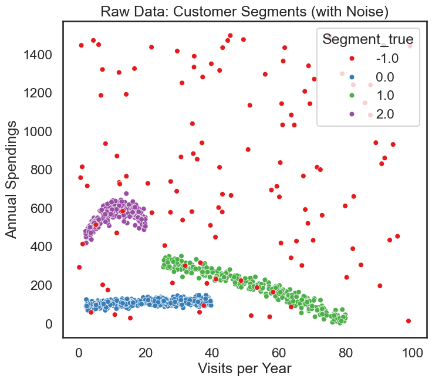

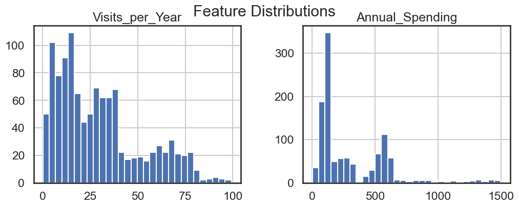

```python
plt.figure(figsize=(8, 7))
sns.scatterplot(
    data=df, x="Visits_per_Year", y="Annual_Spending",
    hue="Segment_true", palette="Set1", s=40
)
plt.title("Raw Data: Customer Segments (with Noise)")
plt.xlabel("Visits per Year")
plt.ylabel("Annual Spendings")
plt.show()

df[["Visits_per_Year", "Annual_Spending"]].hist(bins=30, figsize=(12, 4))
plt.suptitle("Feature Distributions")
plt.show()
```

As we can see the density especially within the low-spending area (because of the high amount of students and employees) is very high, but within that density-area we have two clusters, not just one. So this is something we should pay an eye on later when looking at the density plot.

# **3. Data Preparation (Standardization)**

HDBSCAN is a *distance-based* model. This means the size of the differences between the values within each of the features is essential. Features with higher values might get under-respected because of their larger value-differences => Their density is considered as less compared to features with low value-differences. Therefore we must use standardized values -> z-values.

```python
scaler = StandardScaler()
X_scaled = scaler.fit_transform(df[["Visits_per_Year", "Annual_Spending"]])
```

# **4. Estimating the Hierarchical Density-Based Spatial Clustering of Applications with Noise (HDBSCAN) Model**

In this section we give a *very basic overview* on how HDBSCAN works. If one is interested in more detail how the algorithm works we highly recommend reading the following blog article:  
[Understanding HDBSCAN and Density-Based Clustering](https://pberba.github.io/stats/2020/01/17/hdbscan/)

### **4.1 Density Estimation (KDE) – 3D Visualization**

The following step (density estimation) is actually *not* part of the actual HDBSCAN algorithm, but helps a lot in understanding the principle density-approaches generally use within clustering.

Where the density function is higher, we have more values which have such a value *combination* (x and y) in the dataset. If we immagined the density function (see the plot!) was a landscape of mountaings and valleys, we can do the following experiment: Immagine this landscape is completly covered with water, means all the peaks of the mountains are under water. In this situation we have *no* clusters. Once we start lowering the water-level though, first island/peaks start to appear: Our first clusters. Translated, this means that the water level is our density-threshold we want at least observe to call that group of data a cluster - so areas must be dense enough to be classified as a cluster. Lowering that threshold means that also data points which are farer away from the dense area are now in a dense enough region to be able be part of that cluster. Once the water level is too low though, all mountains are fully above the water-level and are even connected through the valleys. This means all the landscape is one big cluster. Depending on the density threshold - which we basically define through the parameter min_samples - we can adjust how dense data areas must be to be classified as a cluster. This way, also **non-linear** relationships can be modeled and noise is identifiable.

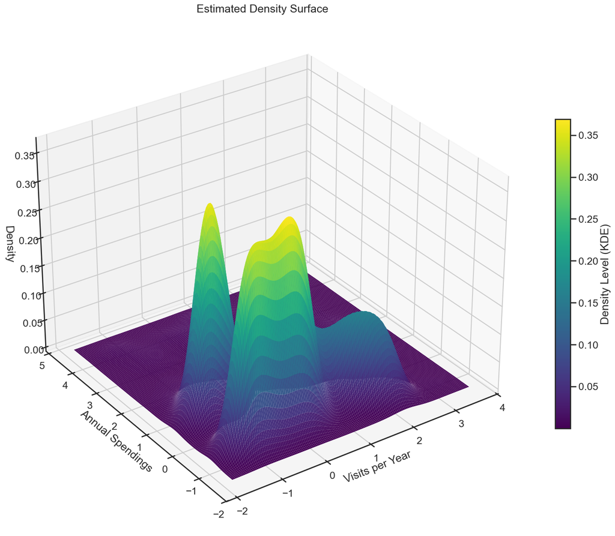

```python
kde = KernelDensity(bandwidth=0.25)
kde.fit(X_scaled)

x_min, x_max = X_scaled[:, 0].min() - 0.5, X_scaled[:, 0].max() + 0.5
y_min, y_max = X_scaled[:, 1].min() - 0.5, X_scaled[:, 1].max() + 0.5

xx, yy = np.meshgrid(
    np.linspace(x_min, x_max, 150),
    np.linspace(y_min, y_max, 150)
)
grid = np.vstack([xx.ravel(), yy.ravel()]).T

density = np.exp(kde.score_samples(grid)).reshape(xx.shape)

# --- 3D Plot ---
fig = plt.figure(figsize=(20, 15))
ax = fig.add_subplot(111, projection="3d")

# Use density as color map values
cmap = cm.viridis
norm = plt.Normalize(vmin=density.min(), vmax=density.max())

surf = ax.plot_surface(
    xx, yy, density,
    cmap=cmap,
    norm=norm,
    rstride=1, cstride=1,
    linewidth=0, antialiased=True
)

fig.colorbar(surf, ax=ax, shrink=0.6, label="Density Level (KDE)")

# Adjusting view degree
ax.view_init(elev=30, azim=235)

ax.set_title("Estimated Density Surface")
ax.set_xlabel("Visits per Year")
ax.set_ylabel("Annual Spendings")
ax.set_zlabel("Density", labelpad=10)
plt.show()
```

### **4.2 Density (Top-Down View)**

This is just another perspective from what we have just seen before - again the estimated density of the data.

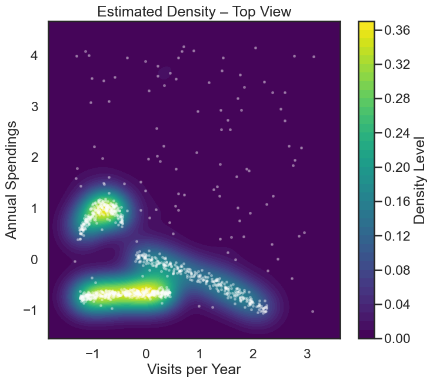

```python
plt.figure(figsize=(8, 7))
cont = plt.contourf(xx, yy, density, levels=40, cmap="viridis")
plt.colorbar(label="Density Level")
plt.scatter(X_scaled[:, 0], X_scaled[:, 1], s=5, color="white", alpha=0.3)
plt.title("Estimated Density – Top View")
plt.xlabel("Visits per Year")
plt.ylabel("Annual Spendings")
plt.show()
```

### **4.3 Estimating the HDBSCAN Model**

Note: The parameters here are just freely chosen "wild guesses" - There were no optimazation methods applied (which do exist and generally should be applyied!!). This was a conscious decision because this notebook should just give an idea of HDBSCAN and how it works and not go into detail regarding HDBSCAN estimation or optimazaiton!

```python
clusterer = hdbscan.HDBSCAN(
    min_cluster_size=35,            # Defines the data points which must at least be present in a cluster
    min_samples=15,                 # Defines "kind of" the density of the area a data point must be present in to be able to be part of a cluster
    metric="euclidean",
    cluster_selection_method="eom"
)
clusterer.fit(X_scaled)

labels_hdb = clusterer.labels_
probs_hdb = clusterer.probabilities_

df["HDBSCAN_Label"] = labels_hdb
df["HDBSCAN_Prob"] = probs_hdb

print("Detected clusters:", len(np.unique(labels_hdb[labels_hdb >= 0])))
print("Noise ratio:", np.mean(labels_hdb == -1)) # -1 = Noise!
```

```
Detected clusters: 3
Noise ratio: 0.08938053097345133
```

### **4.4 HDBSCAN Hierarchy Tree**

To understand this one, one should be already familiar with the general HDBSCAN algorithm (see: [Understanding HDBSCAN and Density-Based Clustering](https://pberba.github.io/stats/2020/01/17/hdbscan/)).

The broad intuition is the following:  
This hierarchy tree is read from top to bottom. lambda is a density-parameter - the higher lambda the higher the density. Here we can see the evolution of the clusters and the three most **stable** ones circeled in red. "Stable" means that these clusters had the highest "surviving-time" based on a decreasing lambda threshold. In the moments when new clusters are generated (= horizontal black lines in the tree plot, splitting a parent-cluster into more clusters) we have a situation where data-points, which previously combined different clusters, broke, because they where in a not dense enough area => new smaller cluster(s).

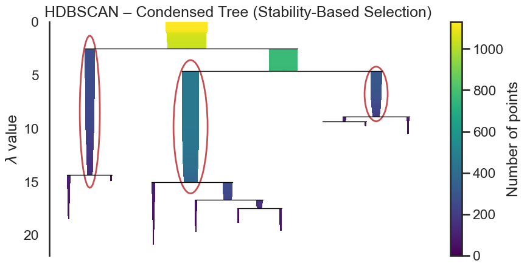

```python
plt.figure(figsize=(10, 5))
clusterer.condensed_tree_.plot(select_clusters=True)
plt.title("HDBSCAN – Condensed Tree (Stability-Based Selection)")
plt.show()
```

### **4.5 HDBSCAN Cluster Plot**

In the following we can seen the results. HDBSCAN is an unsuperviesed machine learning model, where the amount of clusters is not previously decided but decided by the algorithm!

All teh blue points have been defined as noise, labeled with -1.

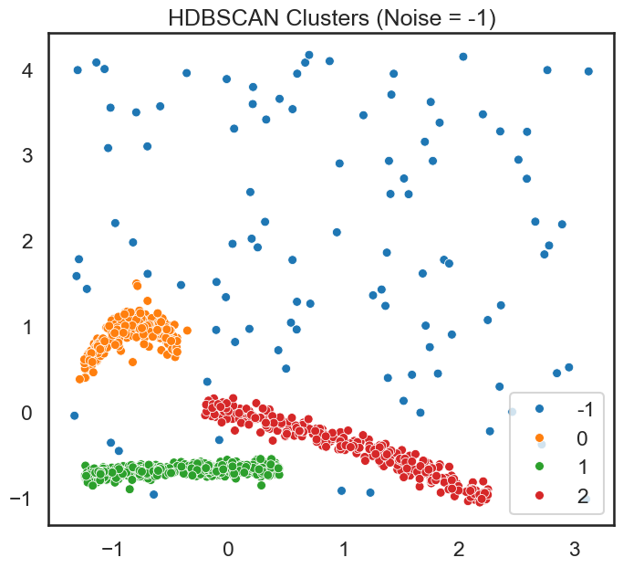

```python
plt.figure(figsize=(8, 7))
sns.scatterplot(
    x=X_scaled[:, 0], y=X_scaled[:, 1],
    hue=labels_hdb, palette="tab10", s=50
)
plt.title("HDBSCAN Clusters (Noise = -1)")
plt.show()
```

# **5. Comparison: HDBSCAN vs KMeans**

This comparison was chosen to show the weaknesses of k-means, which only recognizes linear clusters. We still get the same amount of estimated clusters, but the correct isolation of the individual clusters didn't go correctly.

Additionally, a big advantage of HDBSCAN compared to k-means is the fact that HDBSCAN also defines noise, whereas k-means trys to find a cluster for each data point, which might be missleading in data decisions!

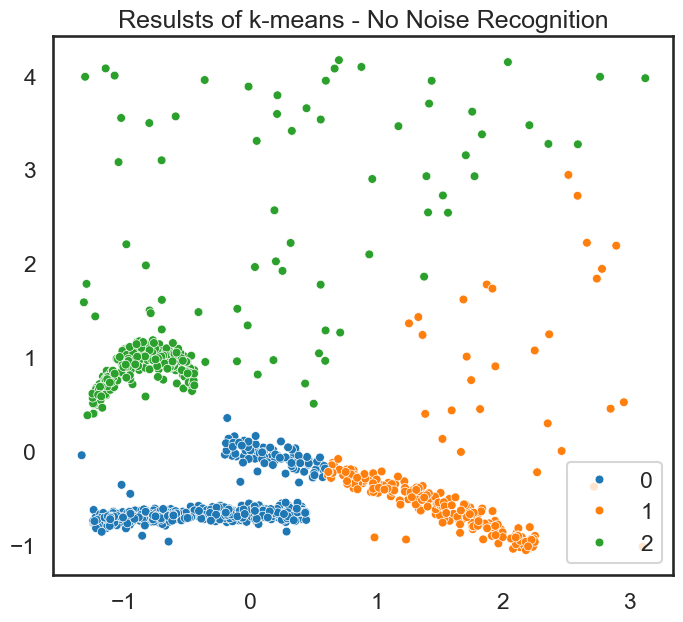

```python
# KMeans
kmeans = KMeans(n_clusters=3, n_init=20)
labels_km = kmeans.fit_predict(X_scaled)

# Visualize KMeans
plt.figure(figsize=(8, 7))
sns.scatterplot(
    x=X_scaled[:, 0], y=X_scaled[:, 1],
    hue=labels_km, palette="tab10", s=40
)
plt.title("Resulsts of k-means - No Noise Recognition")
plt.show()
```